# Homework 1

Mustafa Cömert

13 04 2022

In this homework, we are expected to select at least 3 different measures of interest from *EVDS* of Central Bank of Turkey and at least 1 relevant **search keyword** from *Google Trends*. The purpose of the homework is to get used to data manipulation and visualization of time series objects and interpret correlations among different measures of interest.

# Introduction

As a small individual investor, I started to invest in Borsa Istanbul approximately at the beginning of 2020. Since then, price of the XU100 index went up and down with an increasing trend as well as the volume in the market. In the mean time, USD Dollar/TRY exchange rate increased, too. Therefore, I wondered if there is any correlation between these 3 measeures of interest. My intiution tells me that XU100 price is highly correlated with USD Dollar/TRY exchange rate because they move almost always accordingly. On the other hand, the relation between Dollar rate and XU100 volume is harder to predict since the volume is very volatile lately. Lastly, I somehow sense that as XU100 price goes up, XU100 volume increase similarly.

The other part of the homework is about relevant Google Trends search keywords. I chose *Borsa* term to examine the relation between the interests of people for stock market and stock prices or market volume. Second keyword is *Dolar*. My aim is to find the relation between search volume of Dolar in google trends data and USD Dollar/TRY exchange rate.

Shortly, my research questions are:

- **Are the BIST100 Price and Volume correlated with Dollar Rate or each other?**
- **Are Google Trends search volumes for *Dolar* and *Borsa* keywords correlated with Dollar Rate, BIST100 Price and Volume?**

Let’s examine the questions via visualizations and correlations tests.

# Analaysis

## Data Manipulation and Visualization

Firstly, I picked the *BIST100 Prices*, *BIST100 Volume* and *Dollar Rate* data from [Electronic Data Delivery System (EVDS) of Central Bank of Turkey](https://evds2.tcmb.gov.tr/index.php?/evds/serieMarket). Secondly, *Dolar Search* and *Borsa Search* data are taken from [Google Trends](https://trends.google.com/trends/?geo=TR).

Before reading the data, I activated necessary packages from R.

```r
#visualization package
library(ggplot2)
#package for manipulation of dates
library(lubridate)
#time series package
library(xts)
#forecast package
library(forecast)
#package to plot correlations
library(corrplot)
```

Next, I set the working directory and read the data of each measure of interest in *.csv* format and manipulate them for the sake of visualization purposes.

### 1. EVDS Data (Weekly) :

```r
#set the working directory to read the data
setwd("C:/Users/MUSTAFA CÖM/Desktop/Mustafa/Semester 8/IE360 - Statistical Forecasting/Homeworks/HW1/Data")

#read the weekly evds data in csv format
evds_data <- read.csv(file = "EVDS.csv", header = TRUE, sep = ";")

#change colunm names properly
colnames(evds_data) <- c("Date", "BIST100Price", "BIST100Volume", "DollarRate")

#replace commas with dots then convert variable type from chr to num
evds_data$BIST100Price <- as.numeric(gsub(",", ".",
                                          gsub("\\.", "", evds_data$BIST100Price)))
evds_data$BIST100Volume <- as.numeric(gsub(",", ".",
                                           gsub("\\.", "", evds_data$BIST100Volume)))
evds_data$DollarRate <- as.numeric(gsub(",", ".",
                                        gsub("\\.", "", evds_data$DollarRate)))

#convert date variable from chr to Date
evds_data$Date <- as.Date(evds_data$Date, format = "%Y-%m-%d")

#add years to data as factor
years <- c("2010":"2022")
evds_data$Year <- factor(format(evds_data$Date, "%Y"), levels = years)
```

Here is the summary of EVDS data:

```r
#first 6 rows of the EVDS data
head(evds_data)
```

```
##         Date BIST100Price BIST100Volume DollarRate Year
## 1 2010-01-01       528.25       2617336       1.51 2010
## 2 2010-01-08       547.98       3731992       1.47 2010
## 3 2010-01-15       540.06       3213165       1.45 2010
## 4 2010-01-22       539.97       2633387       1.46 2010
## 5 2010-01-29       546.51       2953866       1.48 2010
## 6 2010-02-05       514.55       3906890       1.48 2010
```

```r
#summary of the EVDS data
str(evds_data)
```

```
## 'data.frame':    642 obs. of  5 variables:
##  $ Date         : Date, format: "2010-01-01" "2010-01-08" ...
##  $ BIST100Price : num  528 548 540 540 547 ...
##  $ BIST100Volume: num  2617336 3731992 3213165 2633387 2953866 ...
##  $ DollarRate   : num  1.51 1.47 1.45 1.46 1.48 1.48 1.51 1.51 1.53 1.53 ...
##  $ Year         : Factor w/ 13 levels "2010","2011",..: 1 1 1 1 1 1 1 1 1 1 ...
```

### 2. Google Trend Data (Monthly) :

```r
setwd("C:/Users/MUSTAFA CÖM/Desktop/Mustafa/Semester 8/IE360 - Statistical Forecasting/Homeworks/HW1/Data")
#read the monthly google trend "Dolar" search data
gt_dolar_data <- read.csv(file = "GTDolar.csv", header = T)
#change the names of the columns
colnames(gt_dolar_data) <- c("Date","DolarSearch")
#change the chr to num
gt_dolar_data$DolarSearch <- as.numeric(gt_dolar_data$DolarSearch)
#replace NA's with 0's
gt_dolar_data$DolarSearch[is.na(gt_dolar_data$DolarSearch)] = 0
#turn months to complete date
gt_dolar_data$Date <- as.Date(parse_date_time(gt_dolar_data$Date,"Ym"),
                              format = "%Y-%m-%d")
#add years to data frame as factors
gt_dolar_data$Year <- factor(format(gt_dolar_data$Date, "%Y"), levels = years)

#read the monthly google trend "Borsa" search data
gt_borsa_data <- read.csv("GTBorsa.csv")
#change the names of the columns
colnames(gt_borsa_data) <- c("Date", "BorsaSearch")
#change the chr to num
gt_borsa_data$BorsaSearch <- as.numeric(gt_borsa_data$BorsaSearch)

#combine gt_borsa and gt_dolar data
gt_data <- cbind(gt_dolar_data, gt_borsa_data[,"BorsaSearch"])
colnames(gt_data) <- c("Date", "DolarSearch", "Year", "BorsaSearch")
```

Here is the summary of Google Trends data:

```r
#summary of Google Trend data
head(gt_data)
```

```
##         Date DolarSearch Year BorsaSearch
## 1 2010-01-01           1 2010          20
## 2 2010-02-01           1 2010          22
## 3 2010-03-01           1 2010          20
## 4 2010-04-01           1 2010          22
## 5 2010-05-01           1 2010          24
## 6 2010-06-01           1 2010          19
```

```r
str(gt_data)
```

```
## 'data.frame':    148 obs. of  4 variables:
##  $ Date       : Date, format: "2010-01-01" "2010-02-01" ...
##  $ DolarSearch: num  1 1 1 1 1 1 1 1 1 1 ...
##  $ Year       : Factor w/ 13 levels "2010","2011",..: 1 1 1 1 1 1 1 1 1 1 ...
##  $ BorsaSearch: num  20 22 20 22 24 19 19 18 23 22 ...
```

### 3. EVDS Data (Monthly) :

I tried to convert weekly data into monthly data by manipulation but I could not managed it and it was very time consuming, so I decided to download monthly data directly and manipulate it to find correlations between monthly EVDS data and Google Trend data

```r
setwd("C:/Users/MUSTAFA CÖM/Desktop/Mustafa/Semester 8/IE360 - Statistical Forecasting/Homeworks/HW1/Data")
#read the monthly evds data in csv format
evds_monthly_data <- read.csv(file = "EVDSmonthly.csv", header = TRUE, sep = ";")
#remove empty rows
evds_monthly_data <- evds_monthly_data[!apply(evds_monthly_data == "", 1, all),]
#change colunm names properly
colnames(evds_monthly_data) <- c("Date", "BIST100Price", "BIST100Volume", "DollarRate")
#replace commas with dots then convert variable type from chr to num
evds_monthly_data$BIST100Price <- as.numeric(gsub(",", ".",
                                  gsub("\\.", "", evds_monthly_data$BIST100Price)))
evds_monthly_data$BIST100Volume <- as.numeric(gsub(",", ".",
                                  gsub("\\.", "", evds_monthly_data$BIST100Volume)))
evds_monthly_data$DollarRate <- as.numeric(gsub(",", ".",
                                  gsub("\\.", "", evds_monthly_data$DollarRate)))
#turn months to complete date
evds_monthly_data$Date <- as.Date(parse_date_time(evds_monthly_data$Date,"Ym"),
                                  format = "%Y-%m-%d")
#add years to data as factor
years <- c("2010":"2022")
evds_monthly_data$Year <- factor(format(evds_monthly_data$Date, "%Y"), levels = years)
```

Here is the summary of Monthly EVDS data:

```r
#first 6 rows of the EVDS data
head(evds_monthly_data)
```

```
##         Date BIST100Price BIST100Volume DollarRate Year
## 1 2010-01-01       546.51       2953866       1.47 2010
## 2 2010-02-01       497.05       2751023       1.51 2010
## 3 2010-03-01       565.38       3402098       1.53 2010
## 4 2010-04-01       589.59       3351656       1.49 2010
## 5 2010-05-01       543.85       1605969       1.53 2010
## 6 2010-06-01       548.39       1782069       1.57 2010
```

```r
#summary of the EVDS data
str(evds_monthly_data)
```

```
## 'data.frame':    148 obs. of  5 variables:
##  $ Date         : Date, format: "2010-01-01" "2010-02-01" ...
##  $ BIST100Price : num  547 497 565 590 544 ...
##  $ BIST100Volume: num  2953866 2751023 3402098 3351656 1605969 ...
##  $ DollarRate   : num  1.47 1.51 1.53 1.49 1.53 1.57 1.54 1.5 1.49 1.42 ...
##  $ Year         : Factor w/ 13 levels "2010","2011",..: 1 1 1 1 1 1 1 1 1 1 ...
```

## Time Plots of EVDS Data

Since I decided use the **autoplot()** function to create time plots of EVDS data, I need to create time series objects for them.

```r
#convert data to time series in order to make time plots with autoplot function
evds_ts <- ts(evds_data[-1], start = 2010, frequency = 52)
```

Finally, we can plot time series of each object:

### 1. Time Plot of **BIST100 Price**

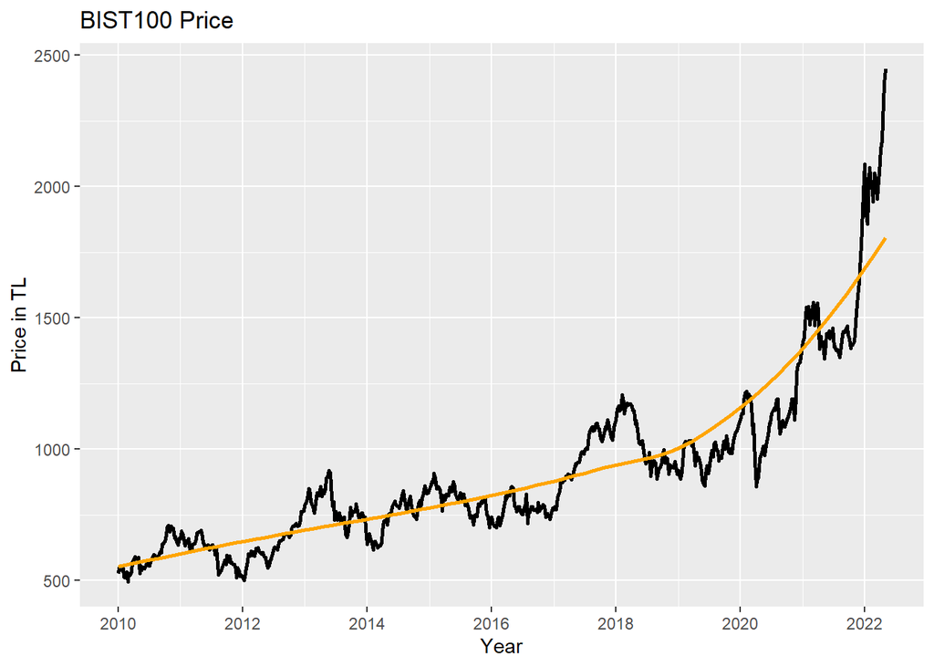

```r
autoplot(evds_ts[,"BIST100Price"], size=1) +
  geom_smooth(fill = NA, color="orange", size = 1) +
  ggtitle("BIST100 Price") + ylab("Price in TL") + xlab("Year")
```

### 2. Time Plot of **BIST100 Volume**

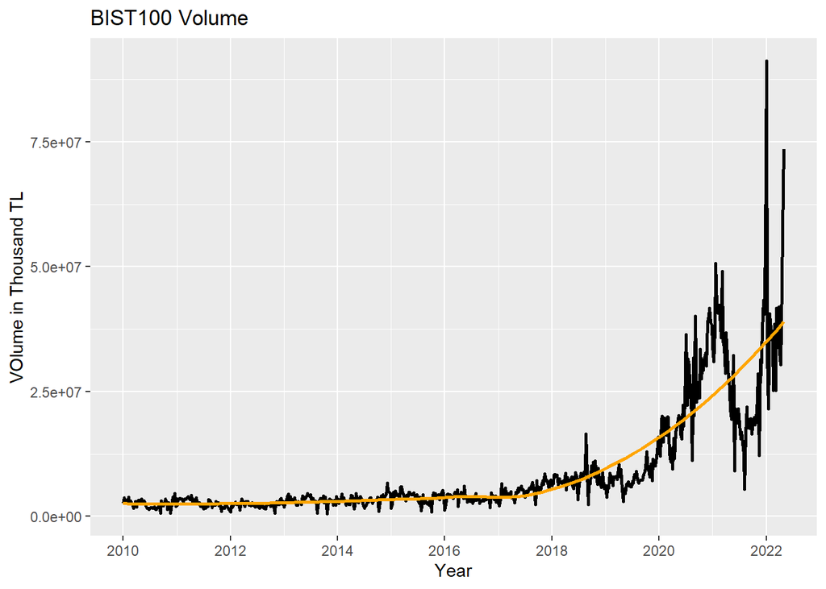

```r
autoplot(evds_ts[,"BIST100Volume"], size=1) +
  geom_smooth(fill = NA, color="orange", size = 1) +
  ggtitle("BIST100 Volume") + ylab("VOlume in Thousand TL") + xlab("Year")
```

### 3. Time Plot of **Dollar Rate**

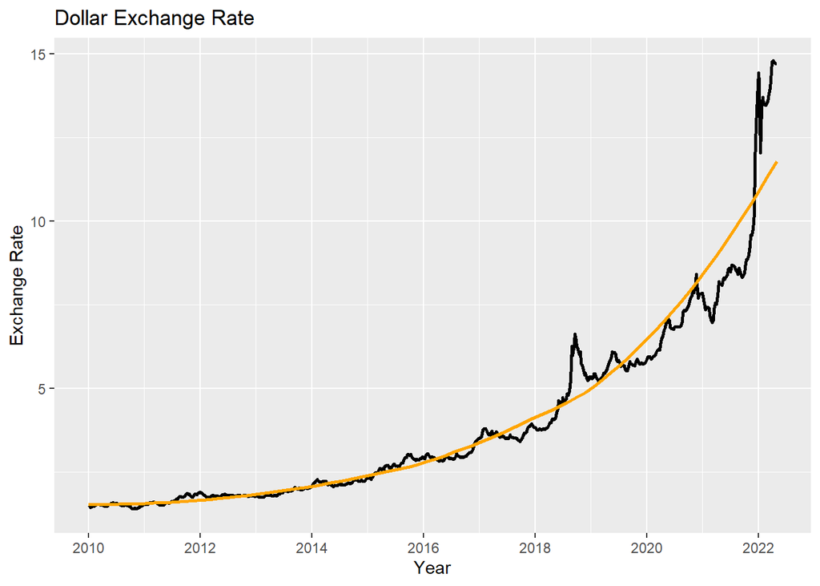

```r
autoplot(evds_ts[,"DollarRate"], size=1) +
  geom_smooth(fill = NA, color="orange", size = 1) +
  ggtitle("Dollar Exchange Rate") + ylab("Exchange Rate") + xlab("Year")
```

When we look at each of the 3 time plots, we can see the similarity in general. Here is some interpretations:

- Especially, *BIST100 Price* and *Dollar Rate* plots are very alike in terms of trends and movements except for *BIST100 Price* is more volatile.
- Trend of the *BIST100 Price* seems linear until 2019 and after that time becomes nonlinear.
- Trend of *Dollar Rate* seems nonlinear all the time between 2010 and 2022.
- On the other hand, *BIST100 Volume* plot seems flat until 2017 (no trend), after that time the volume started to increase significantly similar to other 2 plots.
- *BIST100 Volume* has the highest volatility and is exposed huge fall at 2021 different from other measures.
- Although there are fluctuations on the each plot during positive trend, it is hard to interpret about seasonalities since there is no obvious pattern.

Now, lets draw histograms and box plots for each measures of interest to further explanations.

## Histograms and Box Plots of EVDS Data

We can interpret about frequency distributions via histograms. We graph histograms for each year, thus we can interpret about each year seperately.

Boxplots allow us to interpret data from different perspective. We have 5 number summary of the data, thus we can talk about characteristics of the data and especially about outliers.

### 1. Histogram and Box Plot of **BIST100 Price**

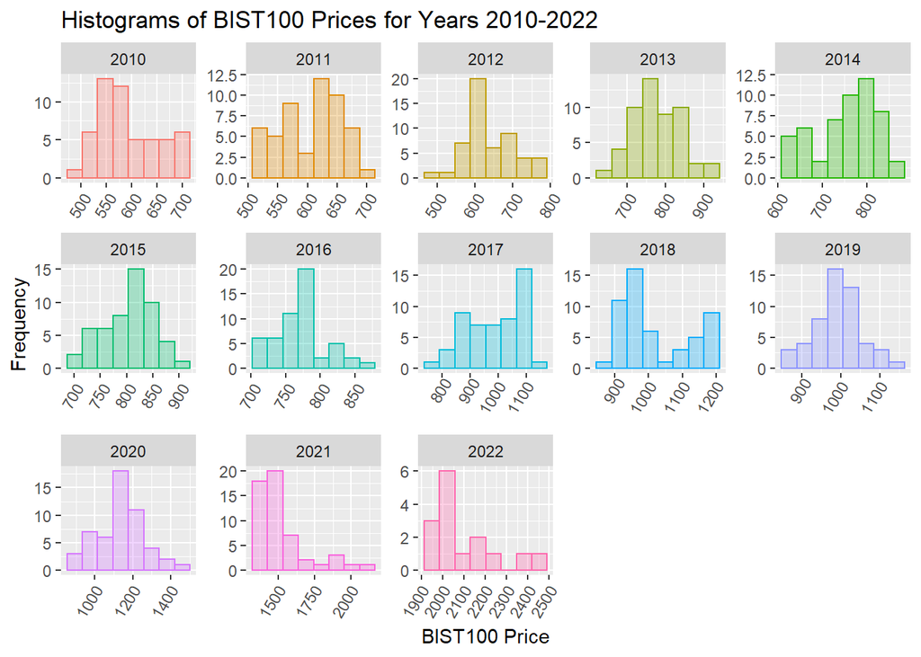

```r
ggplot(data = evds_data, aes(x=BIST100Price)) +
  geom_histogram(bins = 8, alpha = 0.3, aes(color = Year, fill = Year)) +
  facet_wrap(Year~.,scales = "free",ncol = 5) +
  labs(title = "Histograms of BIST100 Prices for Years 2010-2022",
       x = "BIST100 Price",
       y = "Frequency") +
  theme(legend.position = "none") +
  theme(axis.text.x=element_text(angle=60, hjust=1.5, vjust = 1.5))
```

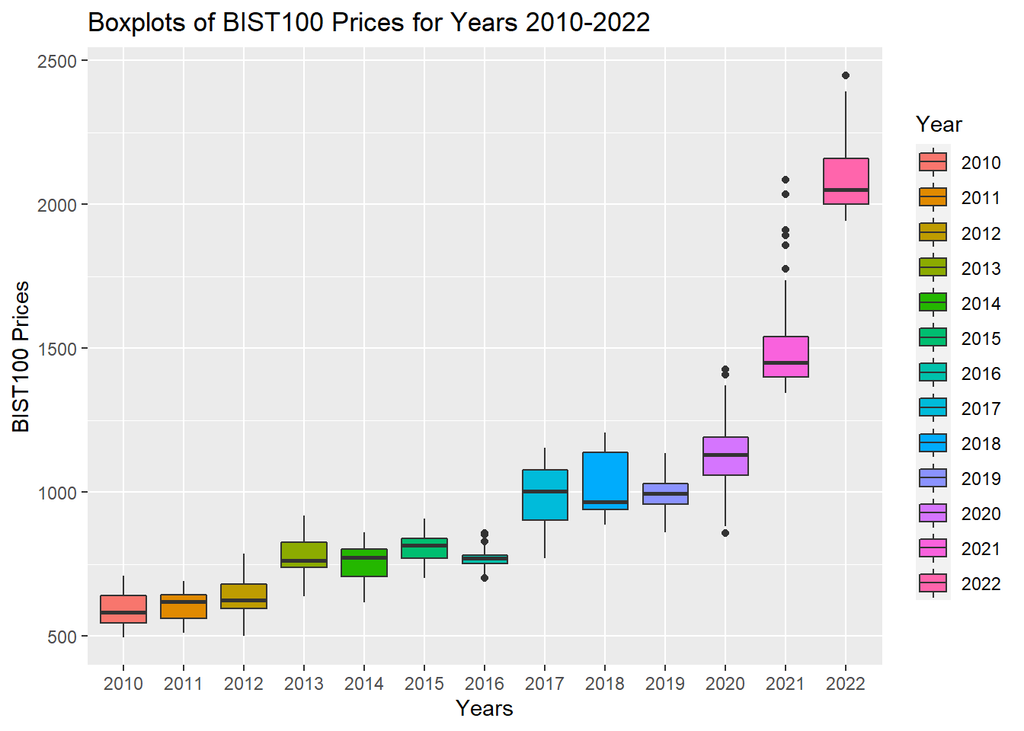

```r
ggplot(data = evds_data, aes(x=Year, y=BIST100Price)) +
  geom_boxplot(aes(y=BIST100Price, fill = Year)) +
  labs(title = "Boxplots of BIST100 Prices for Years 2010-2022",
       x = "Years",
       y = "BIST100 Prices")
```

Box plot of **BIST100 Prices** for each year confirms our comments on histogram. Additionaly:

- In 2021, there are many outliers in the price that make it difficult to interpret.
- It is very obvious that, increment in the price is greater after 2020.

### 2. Histogram and Box Plot of **BIST100 Volume**

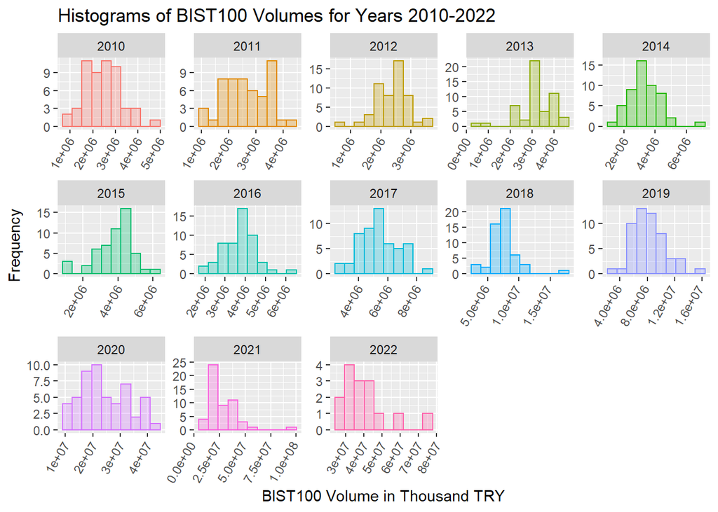

```r
ggplot(data = evds_data, aes(x=BIST100Volume)) +
  geom_histogram(bins = 10, alpha = 0.3, aes(color = Year, fill = Year)) +
  facet_wrap(Year~.,scales = "free",ncol = 5) +
  labs(title = "Histograms of BIST100 Volumes for Years 2010-2022",
       x = "BIST100 Volume in Thousand TRY",
       y = "Frequency") +
  theme(axis.text.x=element_text(angle=60, hjust=1.5, vjust = 1.5)) +
  theme(legend.position = "none")
```

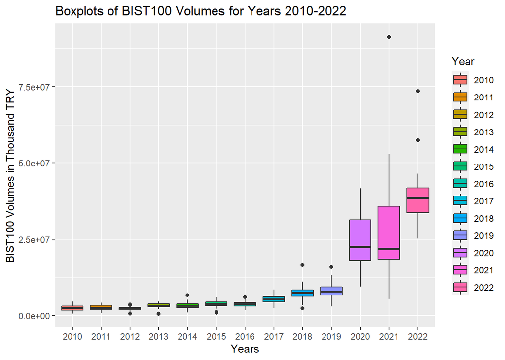

```r
ggplot(data = evds_data, aes(x=Year, y=BIST100Volume)) +
  geom_boxplot(aes(y=BIST100Volume, fill = Year)) +
  labs(title = "Boxplots of BIST100 Volumes for Years 2010-2022",
       x = "Years",
       y = "BIST100 Volumes in Thousand TRY")
```

Similar to BIST100 Price, boxplot of BIST100 Volume confirms my comments on histogram. Additionaly:

- Volume in 2021 has the widest interval and highest outlier value at nearly 90 billion TRY.
- In 2022, there are also some outlier values up to 75 billion TRY.

### 3. Histogram and Box Plot of **Dollar Rate**

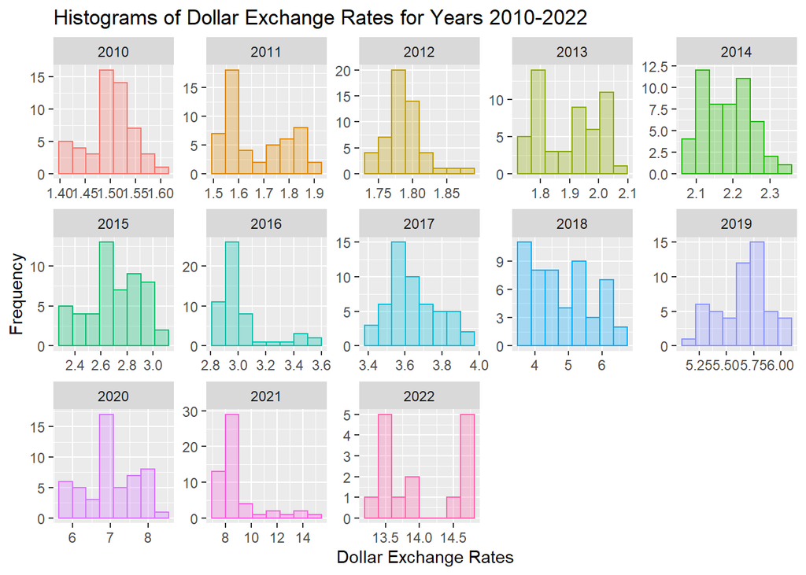

```r
ggplot(data = evds_data, aes(x=DollarRate)) +
  geom_histogram(bins = 8, alpha = 0.3, aes(color = Year, fill = Year)) +
  facet_wrap(Year~.,scales = "free",ncol = 5) +
  labs(title = "Histograms of Dollar Exchange Rates for Years 2010-2022",
       x = "Dollar Exchange Rates",
       y = "Frequency") +
  theme(legend.position = "none")
```

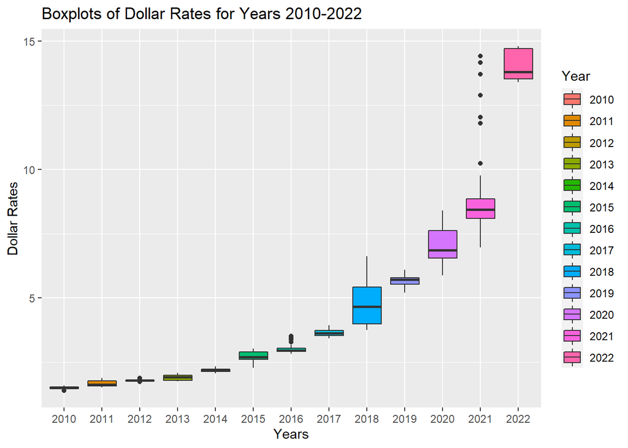

```r
ggplot(data = evds_data, aes(x=Year, y=DollarRate)) +
  geom_boxplot(aes(y=DollarRate, fill = Year)) +
  labs(title = "Boxplots of Dollar Rates for Years 2010-2022",
       x = "Years",
       y = "Dollar Rates")
```

In addition to the comments on histogram which holds:

- We can see an exponential-like increase in USD/TRY exchange rate.
- There are many outliers in 2021 which may be related to outliers of BIST100 Volume.

## Time Plots of Google Trend Data

Before drawing time series plots of Google Trends data, I created time series objects with **ts()** function to use **autoplot()** function.

```r
#convert google trend data to time series object
gt_ts <- ts(gt_data[-1], start = 2010, frequency = 12)
```

### 1. Time Plot of Dolar Search

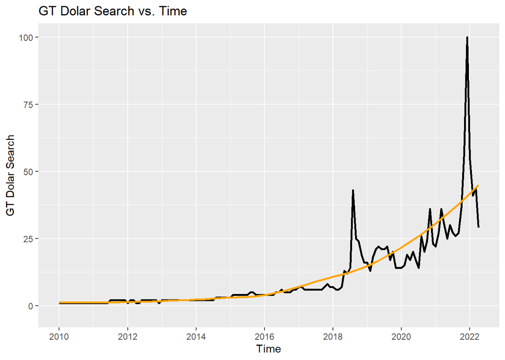

```r
autoplot(gt_ts[,"DolarSearch"],size = 1) +
  geom_smooth(aes(y=gt_ts[,"DolarSearch"]),fill = NA, color="orange",size = 1) +
  labs(title = "GT Dolar Search vs. Time",
       x = "Time",
       y = "GT Dolar Search" )
```

### 2. Time Plot of Borsa Search

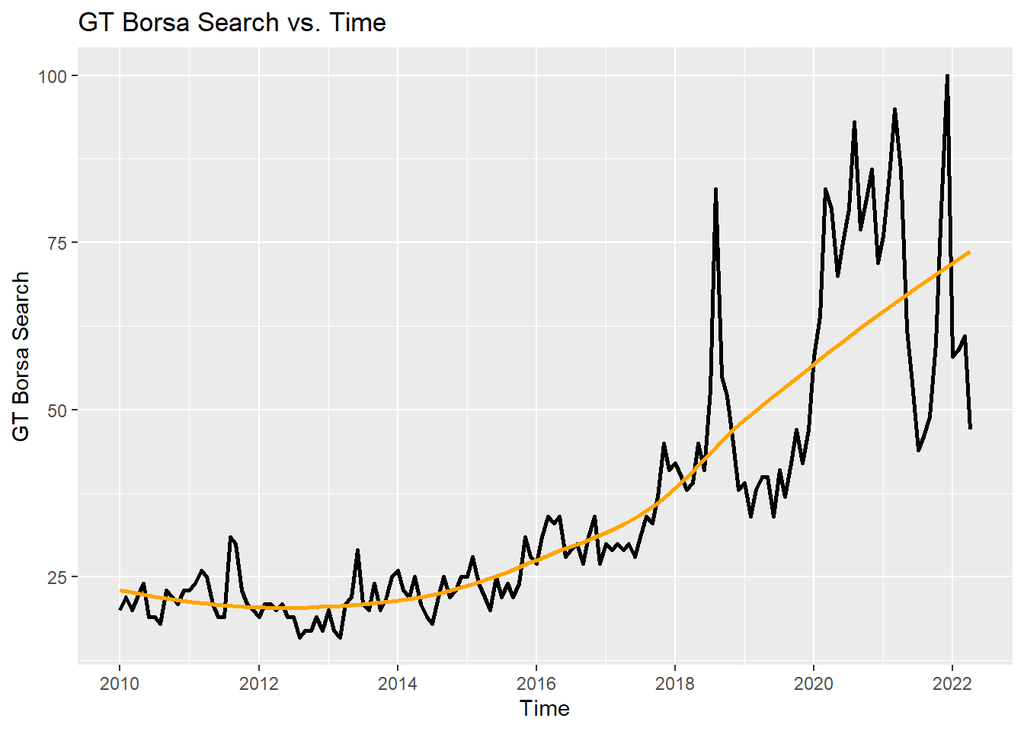

```r
autoplot(gt_ts[,"BorsaSearch"], size=1) +
  geom_smooth(aes(y=gt_ts[,"BorsaSearch"]),fill = NA, color="orange",size = 1) +
  labs(title = "GT Borsa Search vs. Time",
       x = "Time",
       y = "GT Borsa Search" )
```

It is harder to interpret on Google Trends **Borsa Search** time plot. Between 2010-2016, we do not see a significant increase in contrary to **BIST100 Price** but similar to **BIST100 Volume**. After 2017, search volume increases similar to the **BIST100 Price**. However, trend seems linear opposite to the nonlinear increase in price. Moreover, **Borsa Search** is more volatile than **BIST100 Price**. Shortly, we can say that there is some correlations between them but it is weaker than the one between **Dolar Search** and **Dolar Exchange Rate**.

## Box Plots of Google Trend Data

### 1. Box Plot of Dolar Search

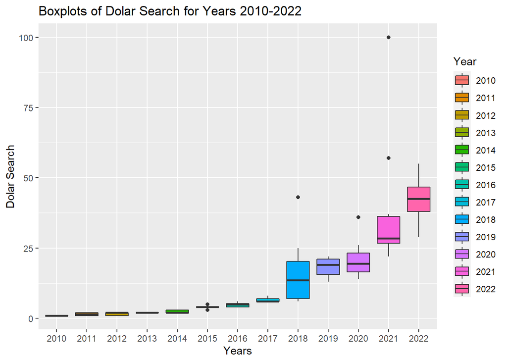

```r
ggplot(data = gt_data, aes(x=Year, y=DolarSearch)) +
  geom_boxplot(aes(y=DolarSearch, fill=Year)) +
  labs(title = "Boxplots of Dolar Search for Years 2010-2022",
       x = "Years",
       y = "Dolar Search")
```

Box plot of **Dolar Search** is very similar to box plot of **Dollar Rate** except for the different increments in 2022.

### 2. Box Plot of Borsa Search

[figure not shown]

```r
ggplot(data = gt_data, aes(x=Year, y=BorsaSearch)) +
  geom_boxplot(aes(y=BorsaSearch, fill=Year)) +
  labs(title = "Boxplots of Dolar Search for Years 2010-2022",
       x = "Years",
       y = "Borsa Search")
```

Box plot of **Borsa Search** seems similar to the box plot of **BIST100 Price** until 2018. After that time, they do not resemble much which points out weak correlation.

## Correlations

Now let’s focus on the relationships between our EVDS data and Google Trends data:

### Correlation between BIST100 Price and Dollar Rate

```r
cor.test(x = evds_data$BIST100Price, y = evds_data$DollarRate,
         method = "pearson", alternative = "greater")
```

```
##
##  Pearson's product-moment correlation
##
## data:  evds_data$BIST100Price and evds_data$DollarRate
## t = 64.935, df = 640, p-value < 2.2e-16
## alternative hypothesis: true correlation is greater than 0
## 95 percent confidence interval:
##  0.9226672 1.0000000
## sample estimates:
##      cor
## 0.931782
```

We can say that there is a strong correlation between **Dolar Rate** and **BIST100 Price** which confirms our early comments.

### Correlation between BIST100 Price and BIST100Volume

```r
cor.test(x = evds_data$BIST100Price, y = evds_data$BIST100Volume,
         method = "pearson", alternative = "greater")
```

```
##
##  Pearson's product-moment correlation
##
## data:  evds_data$BIST100Price and evds_data$BIST100Volume
## t = 40.507, df = 640, p-value < 2.2e-16
## alternative hypothesis: true correlation is greater than 0
## 95 percent confidence interval:
##  0.8288775 1.0000000
## sample estimates:
##       cor
## 0.8481738
```

The correlation between **BIST100 Price** and **BIST100 Volume** is a little weaker than the correlation between **BIST100 Price** and **Dollar Rate**, however it is still very strong.

### Correlation between BIST100 VOlume and Dollar Rate

```r
cor.test(x = evds_data$BIST100Volume, y = evds_data$DollarRate,
         method = "pearson", alternative = "greater")
```

```
##
##  Pearson's product-moment correlation
##
## data:  evds_data$BIST100Volume and evds_data$DollarRate
## t = 41.054, df = 640, p-value < 2.2e-16
## alternative hypothesis: true correlation is greater than 0
## 95 percent confidence interval:
##  0.8324121 1.0000000
## sample estimates:
##       cor
## 0.8513422
```

Soundness of the correlation between **BIST100 Volume** and **Dollar Rate** is very similar to the correlation between **BIST100 Price** and **BIST100 Volume**.

### Correlation between Dollar Rate and Google Trend Dolar Search

```r
cor.test(x = evds_monthly_data$DollarRate, y = gt_data$DolarSearch,
         method = "pearson", alternative = "greater")
```

```
##
##  Pearson's product-moment correlation
##
## data:  evds_monthly_data$DollarRate and gt_data$DolarSearch
## t = 25.13, df = 146, p-value < 2.2e-16
## alternative hypothesis: true correlation is greater than 0
## 95 percent confidence interval:
##  0.8721892 1.0000000
## sample estimates:
##       cor
## 0.9012343
```

We can say that people tend to search dolar more as USD/TRY exchange rate inncreases.

### Correlation between BIST100 Price and Google Trend Borsa Search

```r
cor.test(x = evds_monthly_data$BIST100Price, y = gt_data$BorsaSearch,
         method = "pearson", alternative = "greater")
```

```
##
##  Pearson's product-moment correlation
##
## data:  evds_monthly_data$BIST100Price and gt_data$BorsaSearch
## t = 11.871, df = 146, p-value < 2.2e-16
## alternative hypothesis: true correlation is greater than 0
## 95 percent confidence interval:
##  0.6244671 1.0000000
## sample estimates:
##       cor
## 0.7008108
```

As stated above, **BIST100 Price** and **Borsa Search** is correlated but not as strong as the correlation between **Dollar Rate** and **Dolar Search**.

### Correlation between BIST100 Volume and Google Trend Borsa Search

```r
cor.test(x = evds_monthly_data$BIST100Volume, y = gt_data$BorsaSearch,
         method = "pearson", alternative = "greater")
```

```
##
##  Pearson's product-moment correlation
##
## data:  evds_monthly_data$BIST100Volume and gt_data$BorsaSearch
## t = 13.847, df = 146, p-value < 2.2e-16
## alternative hypothesis: true correlation is greater than 0
## 95 percent confidence interval:
##  0.6881001 1.0000000
## sample estimates:
##       cor
## 0.7534708
```

Similar to price, the volume is correlated to **Borsa Search** but not as much as exchange rate dolar search relation.

## Correlation Plot

We can see the results of whole correlation test visually via correlation plot.

Before doing it, we need to create monthly time series to match all EVDS data and Google Trends data

```r
evds_monthly_data_ts <- cbind(ts(evds_monthly_data[-c(1,5)], start = 2010, frequency = 12),
                              ts(gt_dolar_data$DolarSearch, start = 2010, frequency = 12),
                              ts(gt_borsa_data$BorsaSearch, start = 2010, frequency = 12))
colnames(evds_monthly_data_ts) <- c("BIST100 Price", "BIST100 Volume", "Dollar Rate",
                                    "GT Dolar Search", "GT Borsa Search")
```

Now, we can draw correlation plot:

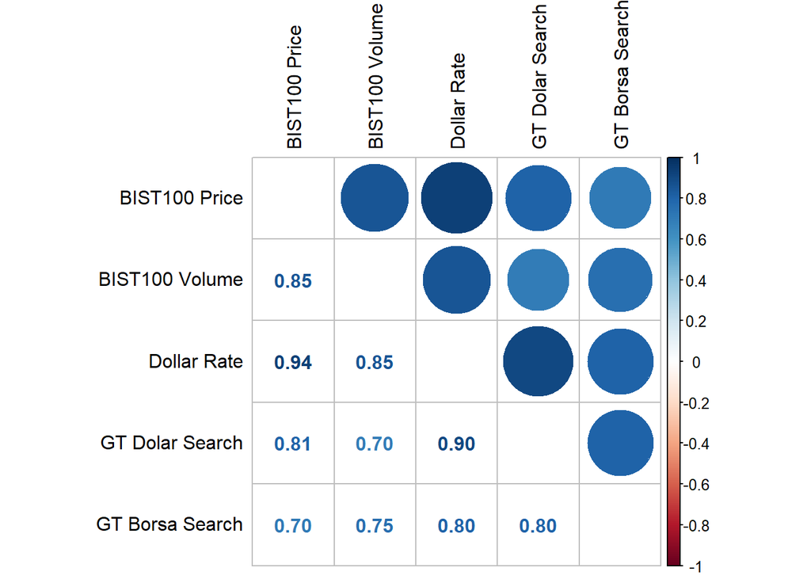

```r
corrplot.mixed(cor(evds_monthly_data_ts, use="pairwise.complete.obs"),
               tl.col="black", tl.pos = "lt")
```

This is the visual representation of all correlations between measures of interest.

## Scatter Plots

Lastly, we can use scatter plots to extend our understanding on correlations.

### Scatter Plots of EVDS Data

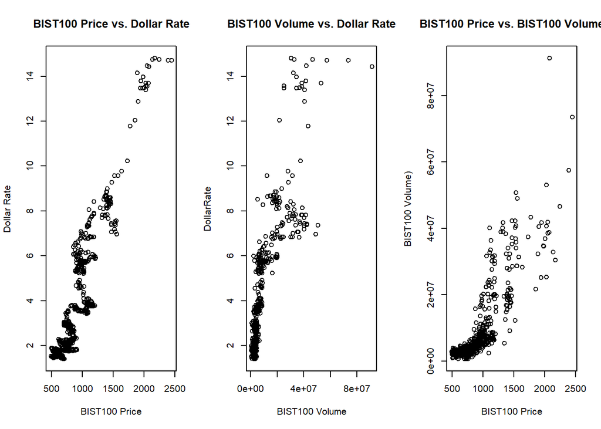

```r
par(mfrow=c(1,3))
plot(x = evds_data$BIST100Price,y = evds_data$DollarRate,
     main = "BIST100 Price vs. Dollar Rate",
     xlab = "BIST100 Price", ylab = "Dollar Rate")
plot(x = evds_data$BIST100Volume,y = evds_data$DollarRate,
     main = "BIST100 Volume vs. Dollar Rate",
     xlab = "BIST100 Volume", ylab = "DollarRate")
plot(x = evds_data$BIST100Price,y = evds_data$BIST100Volume,
     main = "BIST100 Price vs. BIST100 Volume",
     xlab = "BIST100 Price", ylab = "BIST100 Volume)")
```

Between EVDS data, we can easily say that the strongest correlation is between **BIST100 Price** and **Dollar Rate**. Thanks to scatter plot, we can interpret more about the relation. Firstly, the relation between them seems linear. Moreover, we can mention about the presence of some serial dependence. The relation between **Dollar Rate** and **BIST100 Volume** seems linear when dollar rate is betwen 2-6. After that, as dollar rate increases, volume scattered a lot which violates the constant variance assumption. Lastly, the relation between **BIST100 Price** and **BIST100 Volume** seems nonlinear and variance increases as price increases, which violation of constant variance assumption similar to previous relation I mentioned.

### Scatter Plots of EVDS Data vs. Google Trends Data

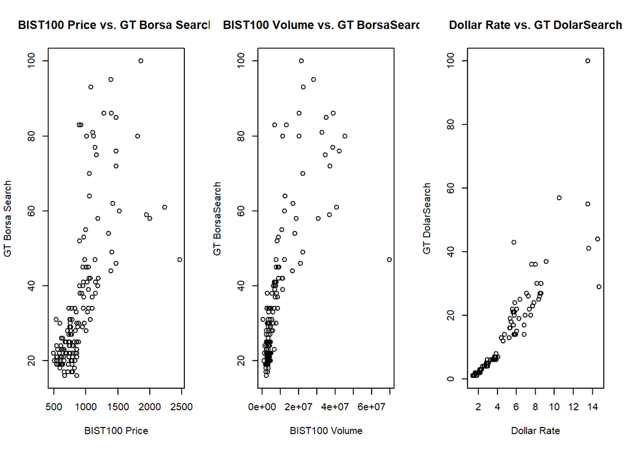

```r
par(mfrow=c(1,3))
plot(x = evds_monthly_data$BIST100Price,y = gt_borsa_data$BorsaSearch,
     main = "BIST100 Price vs. GT Borsa Search",
     xlab = "BIST100 Price", ylab = "GT Borsa Search")
plot(x = evds_monthly_data$BIST100Volume,y = gt_borsa_data$BorsaSearch,
     main = "BIST100 Volume vs. GT BorsaSearch",
     xlab = "BIST100 Volume", ylab = "GT BorsaSearch")
plot(x = evds_monthly_data$DollarRate,y = gt_dolar_data$DolarSearch,
     main = "Dollar Rate vs. GT DolarSearch",
     xlab = "Dollar Rate", ylab = "GT DolarSearch")
```

Firstly, as a consequence of high correlation test results, **Dolar Search** and **Dollar Rate** seems increase accordingly in a linear way. However, as dolar rate exceeds 10, we can see a lot of outlier data points which somehow sabotage the relation. The relation between **BIST100 Volume** and **Borsa Search** seems better than the relation between **BIST100 Price** and **Borsa Search**. Volume and search relation seems nonlinear and violates the constant variance assumption when the volume in the market exceeds 10 billion TRY. Relation between price and search seems linear up to price of 1200. After that point, data scatters a lot and ruins the correlation.

# Conclusion

To sum up, the correlations between **Dollar Rate**, **BIST100 Price** and **BIST100 Volume** are all very high and significant. Especially, **BIST100 Price** moves accordingly to **Dollar Rate**. Other than that, Google Trends **Dolar Search** has a strong correlation with the **Dolar Rate**. Relation between **Borsa Search** and **BIST100 Price** or **BIST100 Volume** is not strong as the relation between dolar search and rate. To reveal the relations between measures of interest fully, further investigations are necessary. However, I can proudly say that they have some strong relations as I suspected.